# Does One Respiratory Virus Protect Against Another? Exploring viral interference from the CASCADIA Cohort

**Biostatistician:** Bethany Akinola, Ayisha Beauge

**Principal Investigator:** Katherine Hoffman, MS; Helen Chu, MD, University of Washington Departments of Biostatistics and Infectious Disease

*July 21, 2026*

# Study background

Respiratory viruses are a leading cause of illness worldwide, with multiple pathogens often circulating simultaneously within communities. Emerging evidence suggests that infection with one respiratory virus may alter an individual’s susceptibility to subsequent infection with another virus, a phenomenon known as **viral interference**. While prior studies have reported both protective and harmful effects of recent viral infections, much of the existing evidence is derived from retrospective electronic health record data with limited longitudinal follow-up.

The CASCADIA Study is a prospective community-based cohort that followed participants across Washington and Oregon between June 2022 and March 2024. Participants completed weekly symptom surveys and self-collected nasal swabs regardless of symptoms, with additional testing during episodes of acute respiratory illness. This intensive surveillance provides a unique opportunity to evaluate how recent respiratory infections influence the risk of future infections in near real time.

The primary analysis, conducted by the University of Washington study team, used time-varying Cox proportional hazards models to estimate whether recent infection with one respiratory virus was associated with increased or decreased risk of subsequent infection with another virus. Exposure windows were defined according to the time elapsed since the prior infection (1–7, 8–14, 15–30, 31–60, 61–90, and 91–180 days).

In this report, we focus on evaluating the robustness of these original findings through a series of planned sensitivity analyses. These analyses assessed whether the primary conclusions remained consistent under alternative analytic assumptions, including different definitions of the washout period used to distinguish new infections from prolonged viral shedding.

# Aims

The objectives of this project were to:

1. Report descriptive statistics regarding patient characteristics and virus prevalence in the overall cohort.
2. Examine whether recent infection with one respiratory virus influences the risk of subsequent infection or reinfection with another respiratory virus.
3. Evaluate the sensitivity of the original findings to alternative washout period definitions used to classify distinct infection events.

# Statistical methods

Cox multivariable regression modeling was used to evaluate the effect of time-varying previous infection exposure on future infection outcomes. The model structure is as follows:

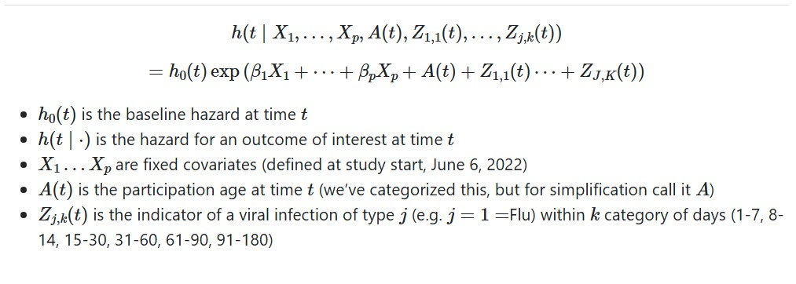

To fit the time-varying Cox model, the data are restructured so that each row represents a one-week person-time interval. Within each interval, recent infections with respiratory pathogens are recorded as time-varying exposures. This approach enables estimation of how prior infection with one virus influences the risk of subsequent infection with another virus across different lag periods.

Forest plots and heat maps are used to visualize exposure hazard ratios.

# Results

## 1. Descriptive statistics of patient characteristics and virus prevalence in the overall cohort

### Patient characteristics

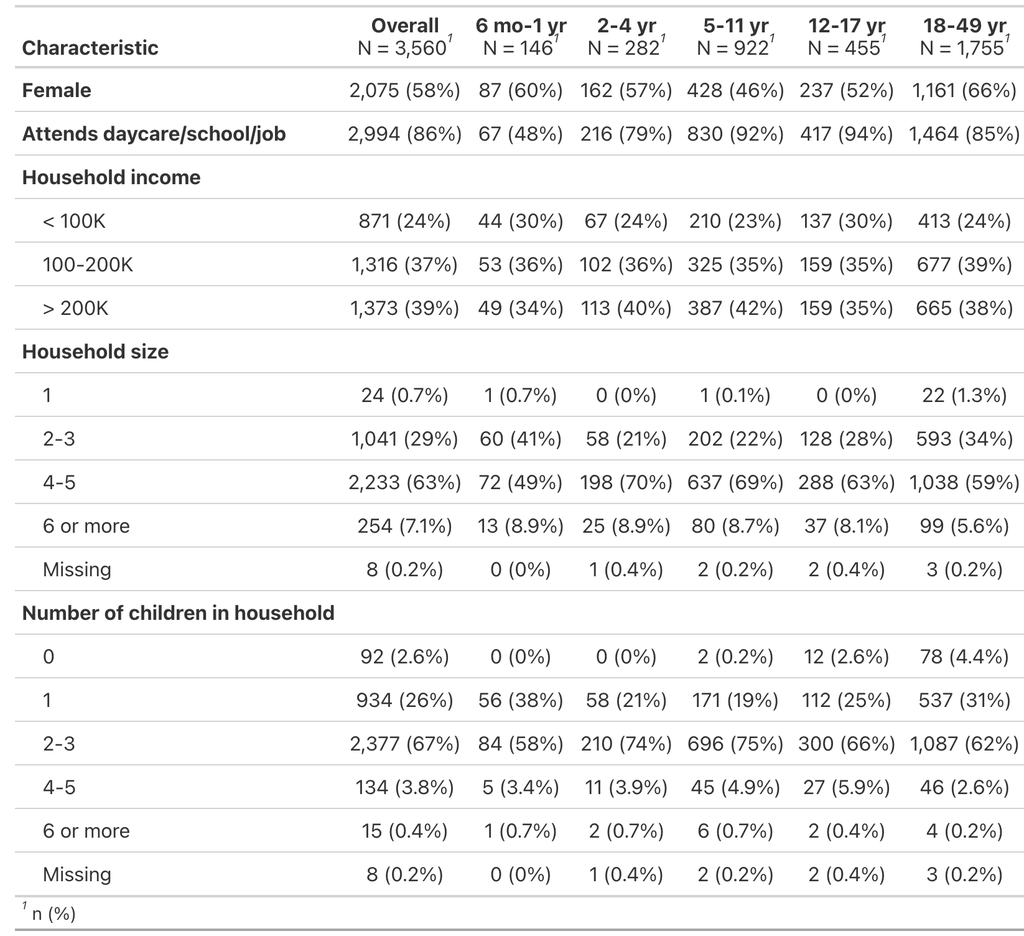

### Infection characteristics

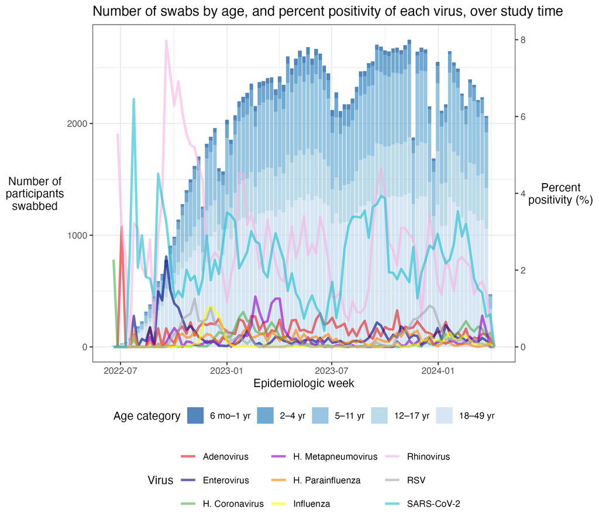

## 2. Forest plots and heat maps of hazard ratios of recent infection exposure on subsequent infection development by infection types and exposure lag

### Day 14

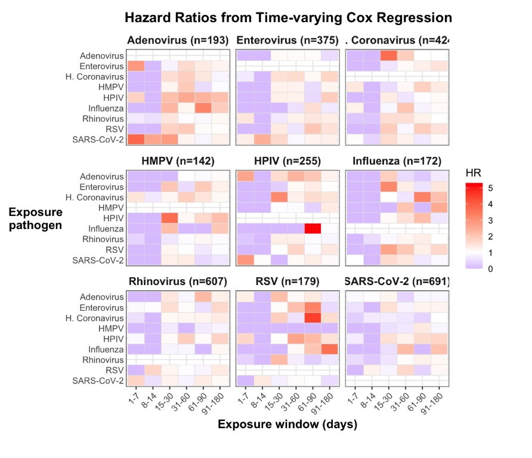

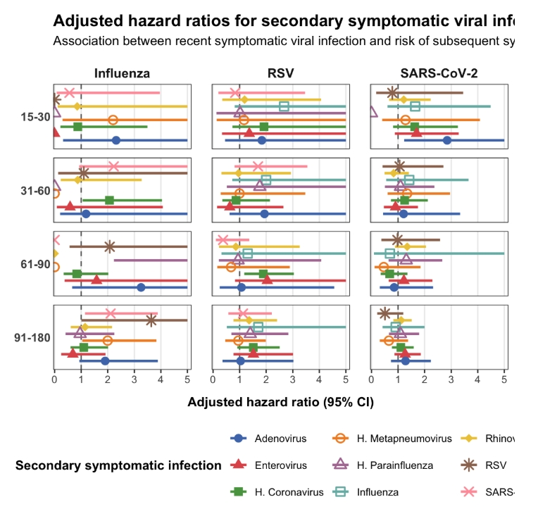

### Day 21

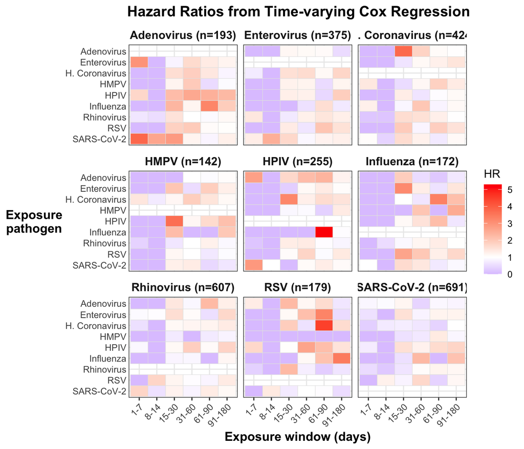

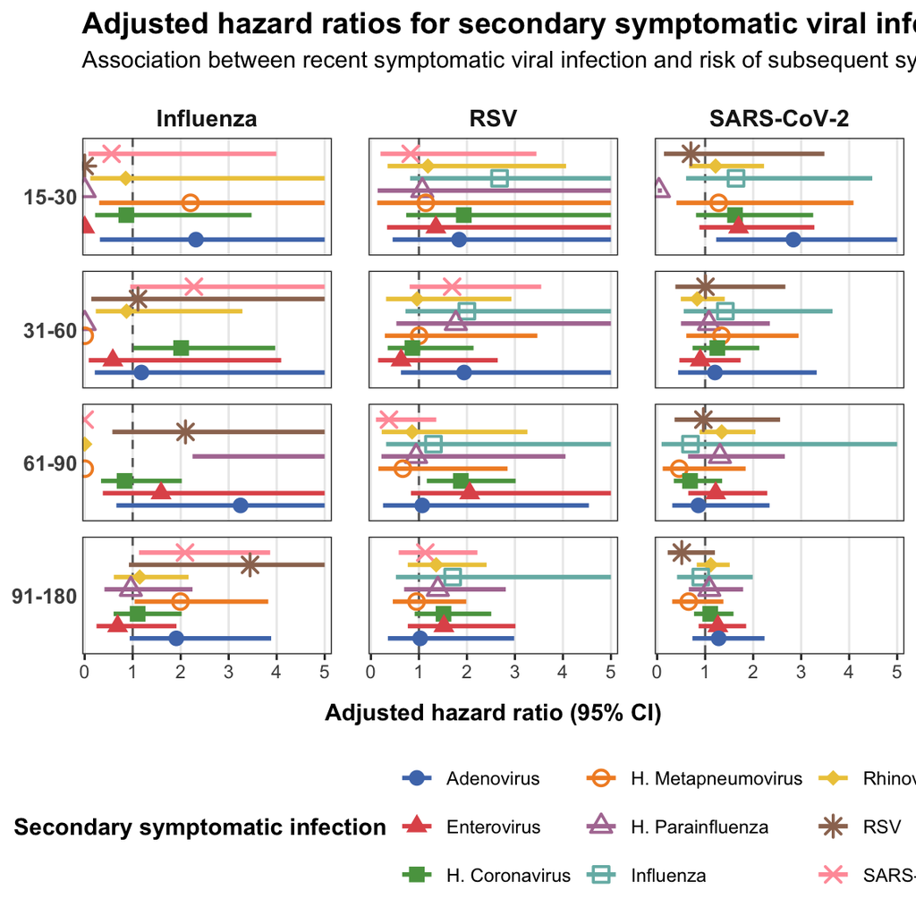

### Day 28

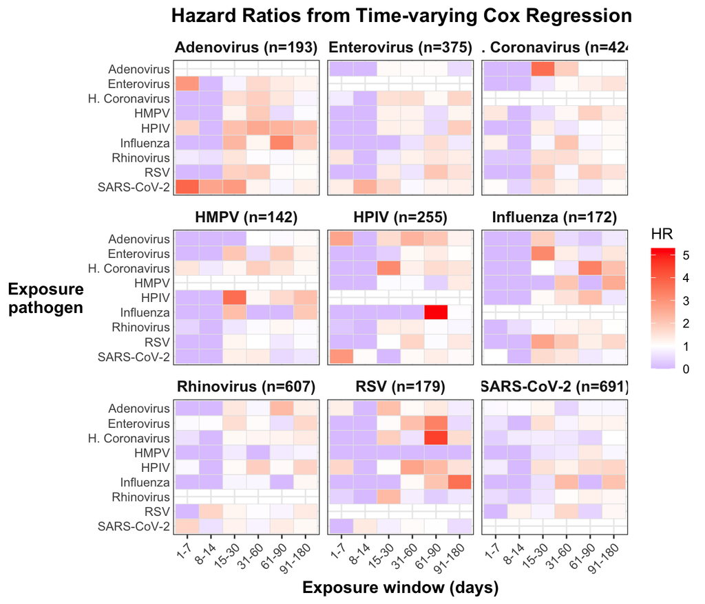

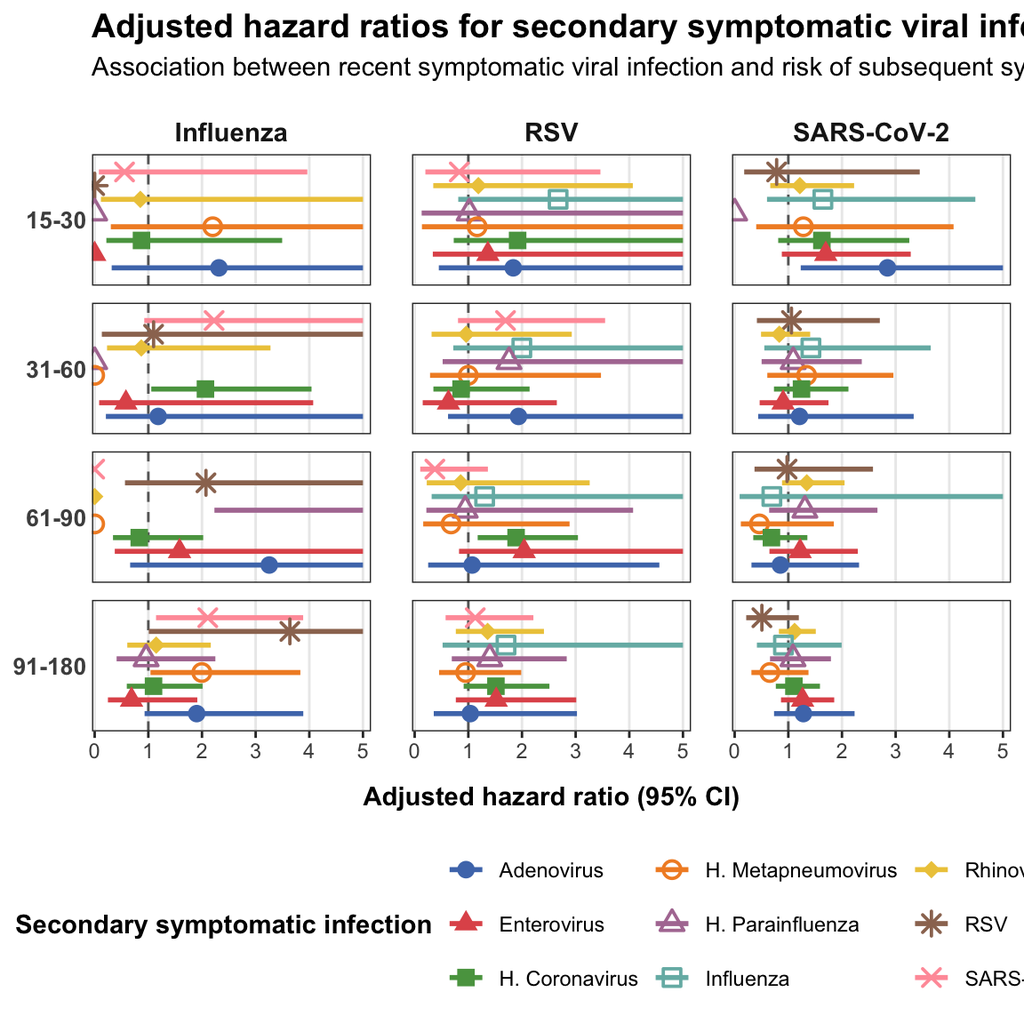

# Conclusions

Overall, short term effects have been observed for all viruses. Recent symptomatic viral infection was associated with time-dependent changes in the risk of secondary symptomatic infections, with the strongest associations observed during the earliest follow-up period (15–30 days). These findings suggest that recent infection may provide temporary protection against some respiratory viruses, although the magnitude and duration of this protection varied across respiratory viral infections. Furthermore, the washout-period dates proves to be robust and sufficient in properly identifying periods of reinfection vs new infection.

### Forest Plots

**Influenza:** Exposure to influenza was associated with a reduced hazard of several secondary symptomatic viral infections during the first 30 days, particularly RSV, H. Parainfluenza virus, and Enterovirus. This apparent protective effect diminished over longer washout periods, with little evidence of sustained protection beyond 90 days. Conversely, protection against some viruses, such as SARS-CoV-2 and rhinovirus, appeared to emerge during intermediate follow-up periods, suggesting that the temporal dynamics of post-infection susceptibility differ by pathogen.**

**RSV:** RSV infection demonstrated limited and inconsistent evidence of protection against subsequent symptomatic infections. Hazard ratios remained near or above one for many viral outcomes across washout periods, indicating that RSV infection may offer less cross-protective immunity than influenza.**

**SARS-CoV-2:** Recent SARS-CoV-2 infection showed limited evidence of protection against secondary respiratory viral infections with the exception of H. Parainfluenza . SARS-CoV-2 infection was also associated with an increased risk of Adenovirus infection during the early post-infection period. Overall, these findings suggest that SARS-CoV-2 provides limited short-term heterologous protection compared with influenza**

# Limitations

Several limitations should be considered when interpreting these findings. First, CASCADIA samples were collected between 2022 and 2024, a period characterized by evolving public health policies, changing mitigation strategies, and varying levels of population immunity, all of which may have influenced individual behaviors, viral exposure, and transmission dynamics. Second, the study population was disproportionately composed of individuals from relatively affluent socioeconomic backgrounds, with approximately 75% identifying as non-Hispanic White. As a result, these findings may not be generalization to populations with lower socioeconomic status or more diverse racial and ethnic backgrounds. Individuals from underserved communities may experience different exposure risks due to factors such as limited ability to isolate, higher-density living environments, and occupations requiring in-person work, which could influence patterns of respiratory viral transmission. Finally, this analysis was restricted to symptomatic infections, limiting the ability to draw conclusions regarding asymptomatic infections and their contribution to subsequent infection risk.

Division of Biostatistics

Department of Population Health Sciences

Bethany Akinola, Ayisha Beauge